# Practicum 10: Model Evaluation

Data Science for Biomedical Informatics (BMIN503/EPID600)

New packages to install for this practicum:

```r
install.packages("GGally")
install.packages("boot")
install.packages("pROC")
```

We will create logistic regression models to predict titanic survivorship using a dataset about [Titanic passengers](http://biostat.mc.vanderbilt.edu/wiki/pub/Main/DataSets/titanic.html) obtained from a repository hosted by [Vanderbilt Biostats](http://biostat.mc.vanderbilt.edu/wiki/Main/DataSets). The data dictionary to understand file variables is [here](https://github.com/HimesGroup/BMIN503/blob/master/DataFiles/titanic3.md). First, let’s get the dataset and clean it. To look quickly at the relationships among variables graphically, we will use a command from the `GGally` package, so install that package if necessary.

```r
library(tidyverse)
library(GGally)
titanic <- read.csv(url("https://raw.githubusercontent.com/HimesGroup/BMIN503/master/DataFiles/titanic3.csv"), header=TRUE)
titanic <- titanic %>%
    select(survived, pclass, sex, age, sibsp, parch) %>%
    filter(complete.cases(.)) %>%
    mutate(survived=factor(survived, levels=c(0, 1), labels=c("died", "lived")))
str(titanic)
```

```
## 'data.frame':    1046 obs. of  6 variables:
##  $ survived: Factor w/ 2 levels "died","lived": 2 2 1 1 1 2 2 1 2 1 ...
##  $ pclass  : int  1 1 1 1 1 1 1 1 1 1 ...
##  $ sex     : Factor w/ 2 levels "female","male": 1 2 1 2 1 2 1 2 1 2 ...
##  $ age     : num  29 0.92 2 30 25 48 63 39 53 71 ...
##  $ sibsp   : int  0 1 1 1 1 0 1 0 2 0 ...
##  $ parch   : int  0 2 2 2 2 0 0 0 0 0 ...
```

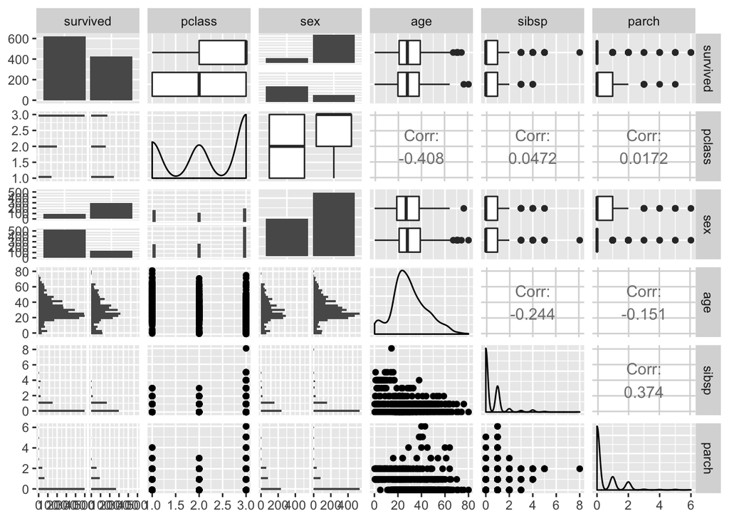

```r
ggpairs(titanic)
```

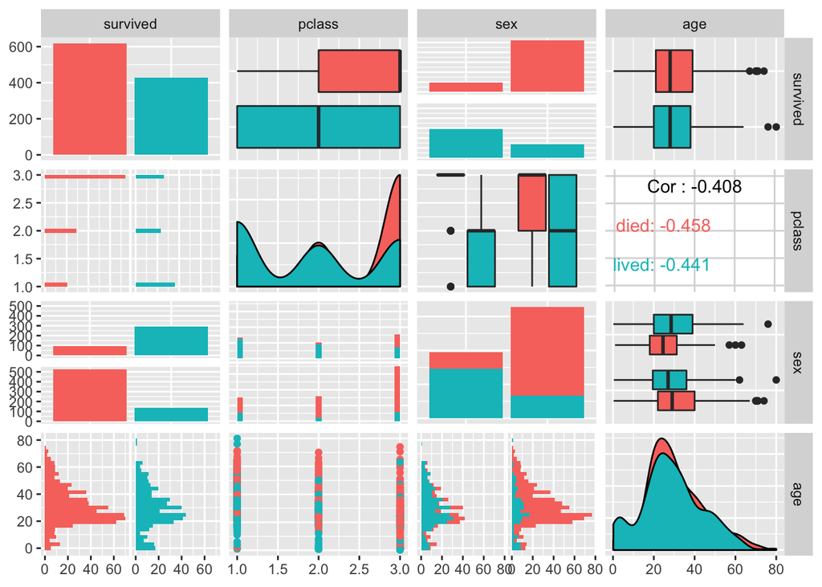

```r
ggpairs(titanic, mapping=aes(col=survived), columns=c("survived", "pclass", "sex", "age"))
```

### Logistic regression

We create the logistic regression model and then obtain the probabilities of surviving according to the training data.

```r
titanic.glm <- glm(survived~., data=titanic, family=binomial(logit))
summary(titanic.glm)
```

```
##
## Call:
## glm(formula = survived ~ ., family = binomial(logit), data = titanic)
##
## Deviance Residuals:
##     Min       1Q   Median       3Q      Max
## -2.6680  -0.6941  -0.4129   0.6471   2.5255
##
## Coefficients:
##              Estimate Std. Error z value Pr(>|z|)
## (Intercept)  4.956785   0.434065  11.419  < 2e-16 ***
## pclass      -1.158154   0.112861 -10.262  < 2e-16 ***
## sexmale     -2.553333   0.173221 -14.740  < 2e-16 ***
## age         -0.038551   0.006544  -5.891 3.83e-09 ***
## sibsp       -0.344904   0.105081  -3.282  0.00103 **
## parch        0.076818   0.099955   0.769  0.44218
## ---
## Signif. codes:  0 '***' 0.001 '**' 0.01 '*' 0.05 '.' 0.1 ' ' 1
##
## (Dispersion parameter for binomial family taken to be 1)
##
##     Null deviance: 1414.62  on 1045  degrees of freedom
## Residual deviance:  971.22  on 1040  degrees of freedom
## AIC: 983.22
##
## Number of Fisher Scoring iterations: 4
```

```r
glm.pred <- predict(titanic.glm, titanic, type="response")
```

### Cross-Validation

When independent data is not available to test a model, we can use cross-validation, which consists using portions of the data at a time to train and test a model. Prediction error is better estimated using cross-validation than on the same data used to train a model, where there is a risk of having an overestimate due to overfitting.

There is a useful function called `cv.glm` which will get a prediction error estimate from a cross-validation of a dataset, but it doesn’t produce the probabilities needed for an AUC curve. Below, we perform cross-validation via a short script.

```r
library(boot)
cost <- function(r, pi=0) mean(abs(r-pi) > 0.5)
titanic.cv.glm <- cv.glm(titanic, titanic.glm, cost, K=10)
summary(titanic.cv.glm)
```

```
##       Length Class  Mode
## call    5    -none- call
## K       1    -none- numeric
## delta   2    -none- numeric
## seed  626    -none- numeric
```

```r
titanic.cv.glm$delta #cross-validation estimate of prediction error
```

```
## [1] 0.2160612 0.2134774
```

```r
#K-Fold Cross Validation
N = nrow(titanic)
K = 10
set.seed(1234)
s = sample(1:K, size=N, replace=T)
pred.outputs.glm <- vector(mode="numeric", length=N)
obs.outputs <- vector(mode="numeric", length=N)
offset <- 0
for(i in 1:K){
    train <- filter(titanic, s != i)
    test <- filter(titanic, s == i)
    obs.outputs[1:length(s[s==i]) + offset] <- test$survived

    #GLM train/test
    glm <- glm(survived~., data=train, family=binomial(logit))
    glm.pred.curr <- predict(glm, test, type="response")
    pred.outputs.glm[1:length(s[s==i]) + offset] <- glm.pred.curr

    offset <- offset + length(s[s==i])
}
```

### ROC Curves

ROC Curves provide an intuitive display of how well a predictive test performs over all possible thresholds that can be used to divide two outcomes. One R package that can create ROC curves and compute associated areas under the ROC curves (AUCs) and confidence intervals is `pROC`.

```r
library(pROC)
roc(titanic$survived, glm.pred, ci=TRUE)
```

```
##
## Call:
## roc.default(response = titanic$survived, predictor = glm.pred,     ci = TRUE)
##
## Data: glm.pred in 619 controls (titanic$survived died) < 427 cases (titanic$survived lived).
## Area under the curve: 0.8457
## 95% CI: 0.8204-0.871 (DeLong)
```

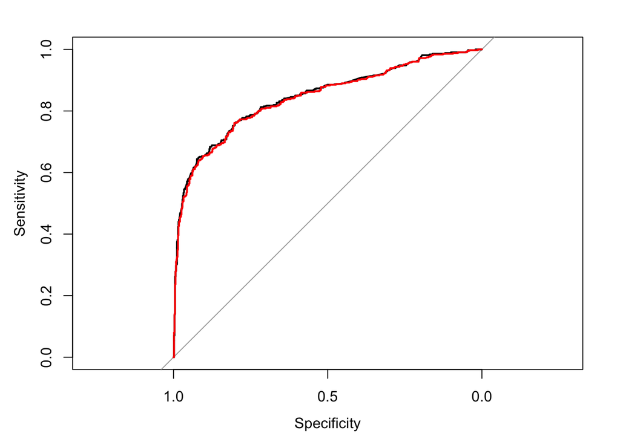

```r
plot.roc(titanic$survived, glm.pred, ci=TRUE)
plot.roc(obs.outputs, pred.outputs.glm, col="red", add=TRUE)
```

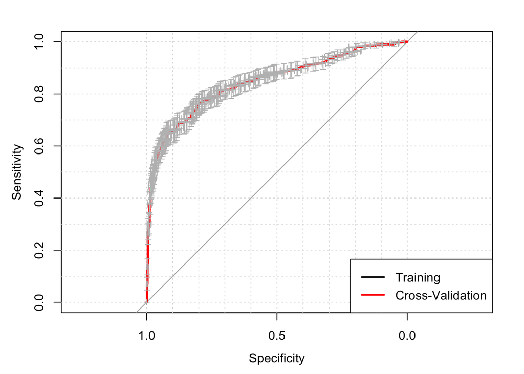

```r
glm.roc <- plot.roc(titanic$survived, glm.pred, col="red", lwd=3, grid=TRUE)
plot(ci.thresholds(glm.roc), col="grey")
legend("bottomright", legend=c("Training", "Cross-Validation"), col=c("black", "red"), lwd=2)
```